# rola-r-tutorial

2025-08-28

# STEP 0: Data Description

## Research Design

This simulated project represents a **clinical trial-style time-series study** analyzed under a **Difference-in-Differences (DiD) framework**. A total of 100 patients are observed daily for 100 days, with multiple electronic health record (EHR) check-ups per day recording heart rate. At the halfway point of the trial (day 50), an intervention is introduced: patients in the treatment group begin receiving a new drug intended to reduce elevated heart rate, while control patients remain untreated.

- **Groups:** Patients are split into treated (receive drug at day 50) and control (never treated).
- **Periods:** Pre-treatment (days 1–49) vs post-treatment (days 50–100).
- **Treatment Effect:** The DiD estimator compares the change in average heart rate before vs after the intervention across treated and control patients. A greater reduction among treated patients relative to controls indicates the causal effect of the drug.

This design mirrors real-world EHR studies where an intervention is rolled out at a fixed time, and differences in pre/post changes between groups are used to estimate impact.

## ehr_did.csv

This file contains the **full dataset** for analysis, combining demographics, trial structure, and repeated EHR measures into a single table with >10,000 rows. Each record corresponds to one check-up for a patient at a specific day and time. Key variables include:

- **patient_id:** Unique identifier for each patient.
- **treated:** Indicator (1 = treatment group, 0 = control group).
- **day:** Day of follow-up (1–100).
- **post:** Indicator (1 = post-intervention period, day ≥ 50; 0 = pre-intervention).
- **datetime:** Exact timestamp of the check-up (to hour/minute).
- **hr:** Heart rate (beats per minute) recorded at that check-up.
- **sex, race, age, bmi, baseline_hr:** Demographic and baseline covariates carried into each row for convenience.

This dataset can be aggregated to daily averages for visualization (e.g., mean daily HR by group) or analyzed as a full longitudinal panel for formal DiD estimation.

# R Pipeline

## STEP 1: LOAD PACKAGES

Key Functions: `library()`

```r
library(tidyverse)
library(lubridate)
library(janitor)
library(lme4)
library(rstanarm)
library(rdrobust)
library(readxl)
```

## STEP 2: LOAD DATA

Key Functions: `read_csv("[path].csv")`, `read_excel("[path].xlsx")`

```r
ehr_did          <- read_csv("ehr_did.csv")
```

## STEP 2: Data Wrangling

Key Functions: `mutate()`, `group_by()`, `select()`, `filter()`,`summarise()`,`pivot_longer()`, `pivot_wider()`

```r
analysis_df <- ehr_did %>%
  mutate(date = as.Date(ymd_hms(datetime))) %>%
  group_by(patient_id, day, treated, post, date) %>%
  summarise(mean_hr = mean(hr), .groups = "drop")
```

## STEP 3: ANALYSIS/Models

Key Functions: `lm()`, `chi.test()`, `t.test()`, etc. Visualizations: `ggplot()`

```r
fit <- lm(mean_hr ~ treated * post, data = analysis_df)
summary(fit)
```

```
##
## Call:
## lm(formula = mean_hr ~ treated * post, data = analysis_df)
##
## Residuals:
##     Min      1Q  Median      3Q     Max
## -29.107  -5.855   0.478   5.902  32.812
##
## Coefficients:
##              Estimate Std. Error t value Pr(>|t|)
## (Intercept)   90.8605     0.2129 426.862  < 2e-16 ***
## treated       -0.7629     0.3010  -2.534   0.0113 *
## post           1.3280     0.2981   4.455 8.47e-06 ***
## treated:post  -8.3187     0.4215 -19.735  < 2e-16 ***
## ---
## Signif. codes:  0 '***' 0.001 '**' 0.01 '*' 0.05 '.' 0.1 ' ' 1
##
## Residual standard error: 10.54 on 9996 degrees of freedom
## Multiple R-squared:  0.1019, Adjusted R-squared:  0.1016
## F-statistic: 378.1 on 3 and 9996 DF,  p-value: < 2.2e-16
```

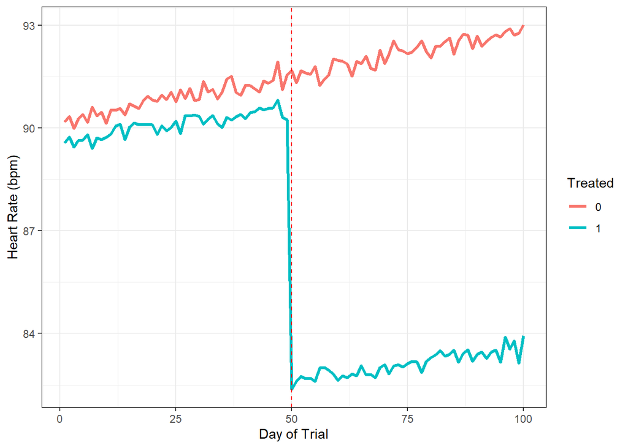

```r
plot_df <- analysis_df %>%
  group_by(day, treated, post) %>%
  summarise(avg_hr = mean(mean_hr), .groups = "drop")

ggplot(plot_df, aes(x = day, y = avg_hr, color = factor(treated))) +
  geom_line(linewidth = 1.2) +
  geom_vline(xintercept = 50, linetype = "dashed", color = "red") +
  labs(
    x = "Day of Trial",
    y = "Heart Rate (bpm)",
    color = "Treated"
  ) +
  theme_bw()
```

## STEP 4: CONCLUSION

The Treatment is Highly Effective p < 0.05.